**Pontifícia Universidade Católica de Minas Gerais**  
**Tópicos em computação I**  
**Prof. Felipe Domingos da Cunha**

*Jully Ketely Alves da Silva*

# Informações do conjunto de dados

Esses conjuntos de dados usados para classificação de nós e aprendizagem por transferência são redes de jogadores usuário-usuário do Twitch que transmitem em um determinado idioma. Os nós são os próprios usuários e os links são amizades mútuas entre eles. Os recursos do Vertex são extraídos com base nos jogos jogados e curtidos, localização e hábitos de streaming. Os conjuntos de dados compartilham o mesmo conjunto de recursos de nó, o que torna possível a transferência de aprendizagem entre redes. Estas redes sociais foram recolhidas em maio de 2018. A tarefa supervisionada relacionada com estas redes é a classificação de nós binários - é preciso prever se um streamer utiliza linguagem explícita.

# **Análise da rede social Twitch usando Python**

```python
!pip install networkx
!pip install matplotlib
!pip install pandas
!pip install Counter
!pip install python-louvain
```

```python
import networkx as nx
import matplotlib.pyplot as plt
import pandas as pd
from collections import Counter
from community import community_louvain
import json
import random
```

### 1.1 Carregamento dos arquivos

```python
# Carregar o arquivo de nós CSV
data = pd.read_csv("data/musae_PTBR_edges.csv")
```

```python
# Criar um grafo direcionado usando o NetworkX
G = nx.Graph()
```

```python
# Adicionar arestas ao grafo com informações do DataFrame
for _, row in data.iterrows():
    G.add_edge(row["from"], row["to"])
```

```python
# Carregar o arquivo JSON com as características dos nós
with open("data/musae_PTBR_features.json", "r") as f:
    features_data = json.load(f)

# Adicionar as características dos nós ao grafo
for node, features in features_data.items():
    G.nodes[int(node)]['features'] = features
```

```python
# Carregar o arquivo CSV com os atributos dos nós
attributes_data = pd.read_csv("data/musae_PTBR_target.csv")

# Adicionar os atributos dos nós ao grafo
for _, row in attributes_data.iterrows():
    node_id = row["new_id"]
    G.nodes[node_id]['days'] = row["days"]
    G.nodes[node_id]['mature'] = row["mature"]
    G.nodes[node_id]['views'] = row["views"]
    G.nodes[node_id]['partner'] = row["partner"]
    G.nodes[node_id]['new_id'] = row["new_id"]
```

### 1.2 Resumo geral do grafo

```python
# Número de nós
num_nodes = len(G.nodes)
print(f"Número de nós: {num_nodes}")

# Número de arestas
num_edges = len(G.edges)
print(f"Número de arestas: {num_edges}")

# Grau médio
avg_degree = sum(d for n, d in G.degree()) / num_nodes
print(f"Grau médio: {avg_degree}")

# Densidade do grafo
density = nx.density(G)
print(f"Densidade: {density}")
```

```
Número de nós: 1912
Número de arestas: 31299
Grau médio: 32.73953974895397
Densidade: 0.017132150575067492
```

### 1.3 Gerando imagem gráfica

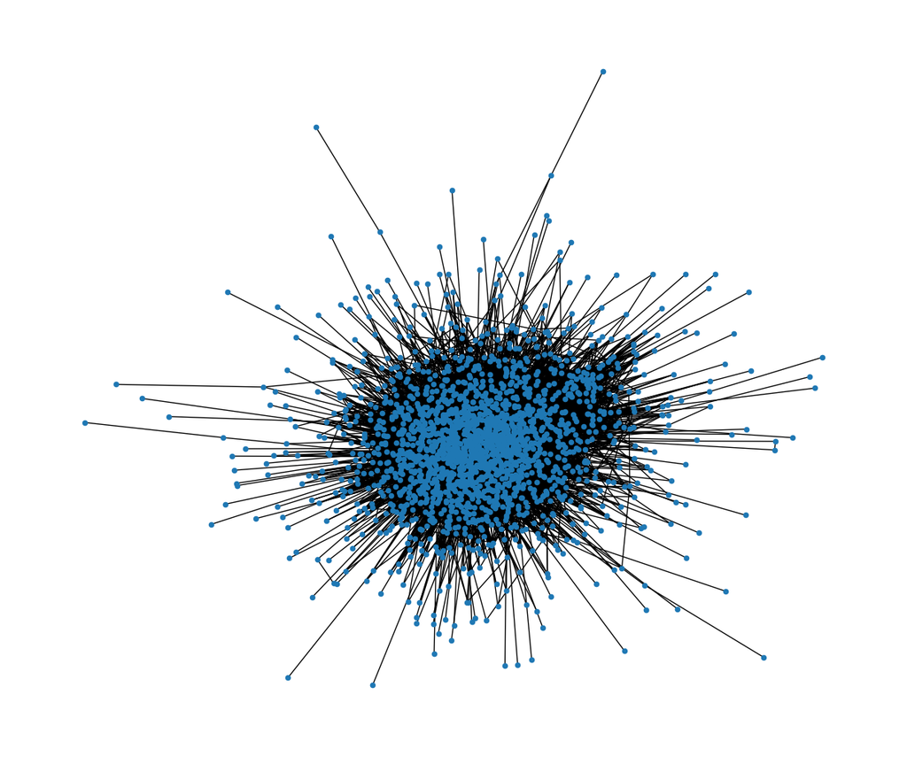

```python
plt.figure(figsize=(12,10))

position = nx.spring_layout(G)

nx.draw(G, pos=position, node_size=20)
```

### 1.4 Distribuição de graus

```python
# Calcular a distribuição de graus
degree_sequence = [d for n, d in G.degree()]
degree_count = Counter(degree_sequence)
degrees, count = zip(*degree_count.items())
```

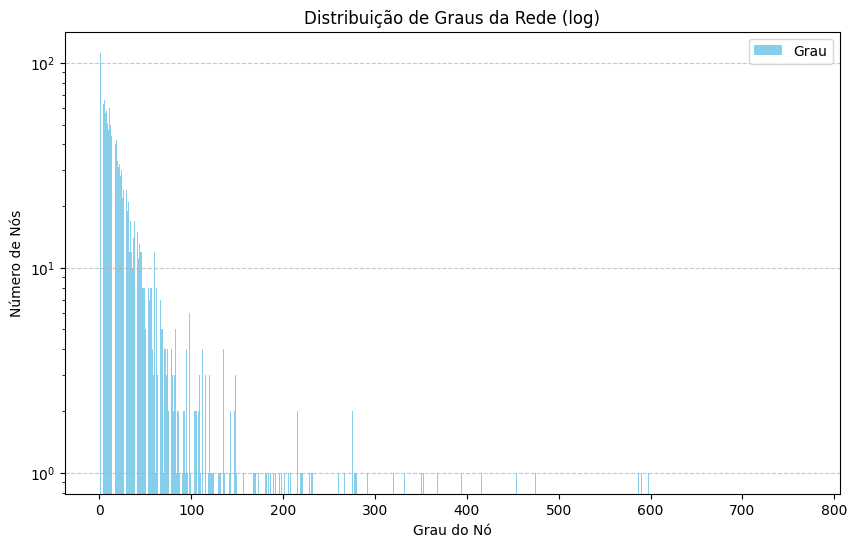

```python
# Exibir a distribuição de graus com personalização
plt.figure(figsize=(10, 6))
plt.bar(degrees, count, width=0.80, color="skyblue")

# Personalizar rótulos e títulos
plt.title("Distribuição de Graus da Rede (log)")
plt.xlabel("Grau do Nó")
plt.ylabel("Número de Nós")

# Definir escala logarítmica no eixo y para uma melhor visualização
plt.yscale('log')

# Adicionar grid para melhor referência
plt.grid(axis='y', linestyle='--', alpha=0.7)

# Adicionar legenda
plt.legend(["Grau"])

plt.show()
```

### 1.5 Variação de gráficos

#### 1.5.1 Detectando comunidades

```python
# Computar os grupos
partitions = community_louvain.best_partition(G)

# Transformar os valores em lista
values = list(partitions.values())
```

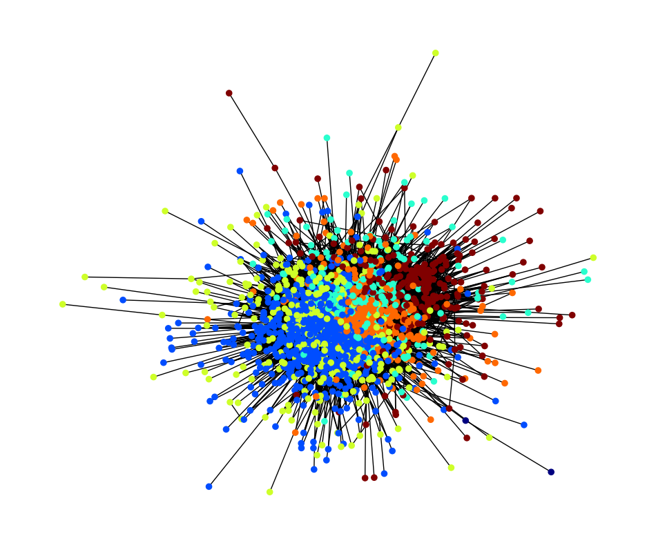

```python
plt.figure(figsize=(12,10))
plt.axis("off")

# Mostrar as diferentes comunidades identificadas seprado por cor
nx.draw_networkx(G, pos=position, cmap=plt.get_cmap("jet"), node_color=values, node_size=35, with_labels=False)
```

#### 1.5.2 Seprarando as comunidades

```python
list(set(values))
```

```
[0, 1, 2, 3, 4, 5]
```

```python
# Seprarar uma comunidade

# Escolha aleatório de comunidade
cluster_id = random.choice(values)

cluster = [node for node in G.nodes() if partitions[node] == cluster_id]
```

```python
# Criar um subgrafo passando os nós selecionados
cluster = G.subgraph(cluster)
```

```
Comunidade escolhida: 2
```

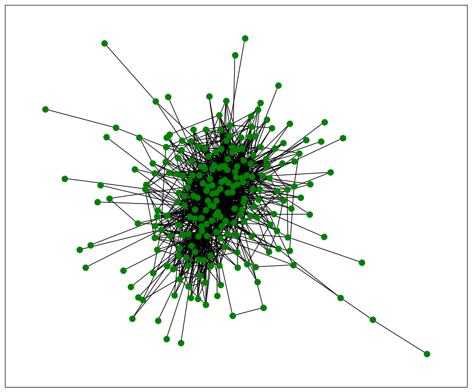

```python
plt.figure(figsize=(12,10))

print(f"Comunidade escolhida: {cluster_id}")


nx.draw_networkx(cluster, node_color='green', node_size=70, with_labels=False)
```

## Análise Final

A rede escolhida foi a rede social do Twitch, uma plataforma de transmissão ao vivo popular entre os interessados em videogames.

O grafo possui 1912 nós, 31299 arestas. O grau médio deu aproximadamente 32,740 e a densidade deu aproximadamente 0,017.

Os dados destacam a proximidade dos nós em relação aos outros. Por exemplo, o grafo inclui o quão intenso é a conexão de um nó aos que estão ao redor, possibilitando a análise de comunidades, como podemos ver na seção 1.5.2, que demonstra o grafo gerado para uma das comunidades identificadas na análise.